# Causal Analysis of Milnepan Treatment for Heffpox

Anita Bosibori

2025-11-10

# Executive Summary

**Research Question:** Does Milnepan treatment *cause* a reduction in death risk among heffpox patients

**Casual Effects Estimated:**

- Average Treatment Effect (ATE): Effect if we treated everyone vs. no one
- Average Treatment Effect on Treated (ATT): Effect among those who received treatment
- Conditional Average Treatment Effect (CATE): Effect modification by diabetes status

**Methods:** Inverse Probability Weighting (IPW), Propensity Score Matching, and G-computation with multiple imputation for missing data.

# 1. Introduction

## Background

Heffpox is a serious disease with high mortality within 7 days of diagnosis. Milnepan is a newly discovered treatment hypothesized to reduce death risk. This analysis examines whether prescribing milnepan causally reduces mortality using observational data from Hundred Acre Hospital.

## Causal Framework

This is a causal inference problem because:

1. **Confounding:** Patients who receive milnepan may differ systematically from those who don’t (e.g., healthier patients may be more likely to receive treatment)
2. **Missing counterfactuals:** We cannot observe what would have happened to treated patients had they not been treated
3. **Goal:** Estimate the causal effect, not just association

We address confounding through: - Directed Acyclic Graphs (DAGs) to identify confounders - Propensity score methods - Multiple causal inference approaches for robustness

# Setup and Data Loading

```r
# Core packages
library(tidyverse)
library(survival)

# Missing data
library(mice)
library(naniar)

# Tables and visualization
library(gtsummary)
library(kableExtra)

# Causal inference
library(MatchIt)
library(WeightIt)
library(cobalt)
library(dagitty)

# Set theme
theme_set(theme_minimal())
```

```r
# Load the dataset
heffpox <- read_csv("../Data/heffpox_2425 (1).csv")

# Initial look at the data
glimpse(heffpox)
```

```
## Rows: 8,889
## Columns: 12
## $ ID        <dbl> 1, 2, 3, 4, 5, 6, 7, 8, 9, 10, 11, 12, 13, 14, 15, 16, 17, 1…
## $ heffpox   <dbl> 1, 1, 1, 1, 1, 1, 1, 1, 1, 1, 1, 1, 1, 1, 0, 1, 1, 1, 1, 1, …
## $ sex       <dbl> 1, 1, 0, 1, 1, 0, 1, 1, 1, 0, 0, 0, 0, 1, 1, 0, 1, 1, 0, 1, …
## $ age       <dbl> 81, 37, 59, 59, 27, 58, 37, 60, 79, 20, 77, 26, 53, 63, 22, …
## $ bmi       <dbl> 23.67111, 24.73449, 28.51908, 25.31838, 32.19974, NA, 27.752…
## $ smoking   <dbl> 1, 0, 0, 0, 0, 0, 0, 0, 1, 1, 0, 0, 1, 1, 0, 0, 1, 0, 0, 1, …
## $ diabetes  <dbl> 1, 0, 0, 1, 0, 0, 0, 1, 0, 0, 0, 0, 0, 0, 0, 0, 0, 0, 0, 0, …
## $ milnepan  <dbl> 0, 0, 0, 1, 1, 0, 0, 1, 0, 0, 0, 0, 1, 1, 1, 0, 1, 1, 1, 0, …
## $ icu       <dbl> 0, 1, 1, 0, 0, 1, 0, 1, 0, 0, 0, 0, 0, 0, 0, 0, 0, 1, 0, 0, …
## $ TEVENT    <dbl> 5.44924107, 0.11493306, 0.53523744, 4.57581488, 7.69967248, …
## $ Status    <dbl> 1, 1, 1, 1, 1, 1, 1, 1, 1, 0, 0, 1, 1, 1, 0, 1, 1, 1, 1, 1, …
## $ death7day <dbl> 1, 1, 1, 1, 0, 1, 1, 1, 0, 0, 0, 1, 1, 1, 0, 0, 1, 1, 1, 0, …
```

**Dataset description:**

- **N = 8889 patients**
- **Variables:** ID, heffpox diagnosis, demographics (sex, age, BMI), risk factors (smoking, diabetes), treatment (milnepan), ICU admission, time-to-event data (TEVENT, Status), and 7-day death indicator

# Data Cleaning

## Filter to Heffpox Patients

The research question concerns patients diagnosed with heffpox. Patients without heffpox are excluded as they are not the target population.

```r
# Check distribution
table(heffpox$heffpox)
```

```
##
##    0    1
##  670 8219
```

```r
# Keep only heffpox patients
heffpox_clean <- heffpox %>%
  filter(heffpox == 1) %>%
  select(-heffpox, -ID)  # Remove unnecessary variables

cat("Original dataset:", nrow(heffpox), "patients\n")
```

```
## Original dataset: 8889 patients
```

```r
cat("After filtering:", nrow(heffpox_clean), "patients with heffpox\n")
```

```
## After filtering: 8219 patients with heffpox
```

**Analytical sample:** N = 8219 heffpox patients.

# Exploratory Data Analysis

## Missing Data Assessment

```r
# Missing data summary
miss_var_summary(heffpox_clean) %>%
  kable(caption = "Missing Data Summary") %>%
  kable_styling(bootstrap_options = c("striped", "hover"))
```

Missing Data Summary

| variable | n_miss | pct_miss |
| --- | --- | --- |
| bmi | 2718 | 33.1 |
| smoking | 365 | 4.44 |
| sex | 0 | 0 |
| age | 0 | 0 |
| diabetes | 0 | 0 |
| milnepan | 0 | 0 |
| icu | 0 | 0 |
| TEVENT | 0 | 0 |
| Status | 0 | 0 |
| death7day | 0 | 0 |

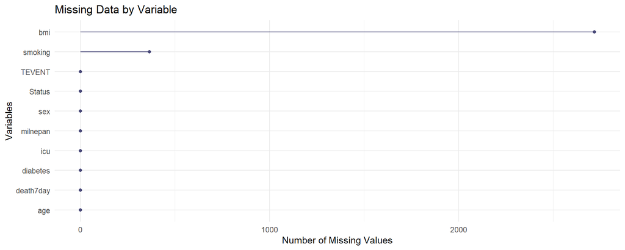

```r
gg_miss_var(heffpox_clean) +
  labs(title = "Missing Data by Variable",
       y = "Number of Missing Values")
```

```r
# shows in the report

# Save the plot in your Figures folder
ggsave("C:/Users/PC/OneDrive/Desktop/Current Project/Output/Figures/missing-visualization.png", width = 7, height = 5)
```

**Key findings:**

- BMI has ~33% missing data
- Smoking has ~4% missing data
- All other variables are complete

Missing data will be handled via multiple imputation.

## Descriptive Statistics by Treatment Group

```r
heffpox_clean %>%
  select(milnepan, sex, age, bmi, smoking, diabetes,
         icu, Status, death7day) %>%
  tbl_summary(
    by = milnepan,
    statistic = list(
      all_continuous() ~ "{mean} ({sd})",
      all_categorical() ~ "{n} ({p}%)"
    ),
    label = list(
      sex ~ "Sex (Male)",
      age ~ "Age (years)",
      bmi ~ "BMI (kg/m²)",
      smoking ~ "Current Smoker",
      diabetes ~ "Diabetes",
      icu ~ "ICU Admission",
      Status ~ "Died",
      death7day ~ "Death within 7 days"
    ),
    missing_text = "Missing"
  ) %>%
  add_overall() %>%
  add_p() %>%
  modify_header(label ~ "**Variable**") %>%
  bold_labels()
```

| **Variable** | **Overall** N = 8,219<sup>1</sup> | **0** N = 4,367<sup>1</sup> | **1** N = 3,852<sup>1</sup> | **p-value**<sup>2</sup> |
| --- | --- | --- | --- | --- |
| Sex (Male) | 3,964 (48%) | 2,071 (47%) | 1,893 (49%) | 0.12 |
| Age (years) | 44 (18) | 49 (20) | 40 (13) | <0.001 |
| BMI (kg/m²) | 28.0 (4.0) | 27.8 (4.0) | 28.1 (4.0) | 0.002 |
| Missing | 2,718 | 1,505 | 1,213 |  |
| Current Smoker | 2,017 (26%) | 1,127 (27%) | 890 (24%) | 0.002 |
| Missing | 365 | 215 | 150 |  |
| Diabetes | 799 (9.7%) | 588 (13%) | 211 (5.5%) | <0.001 |
| ICU Admission | 878 (11%) | 539 (12%) | 339 (8.8%) | <0.001 |
| Died | 4,092 (50%) | 2,376 (54%) | 1,716 (45%) | <0.001 |
| Death within 7 days | 3,338 (41%) | 1,942 (44%) | 1,396 (36%) | <0.001 |

<sup>1</sup> n (%); Mean (SD)  
<sup>2</sup> Pearson’s Chi-squared test; Wilcoxon rank sum test

**Conclusion:** Simple comparison is biased. We need causal methods to adjust for confounding.

## Survival Analysis - Time to Event

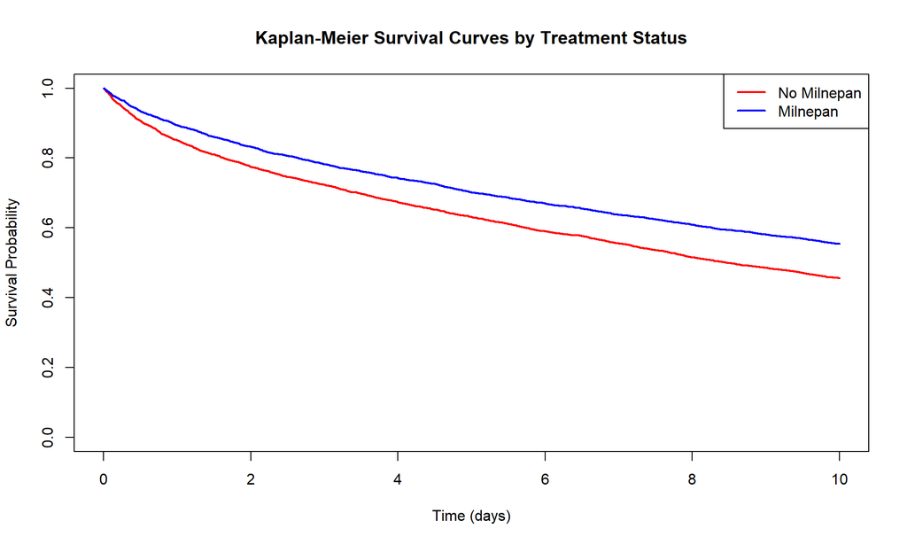

```r
# Kaplan-Meier curves by treatment
km_fit <- survfit(Surv(TEVENT, Status) ~ milnepan, data = heffpox_clean)

# Plot
plot(km_fit,
     col = c("red", "blue"),
     xlab = "Time (days)",
     ylab = "Survival Probability",
     main = "Kaplan-Meier Survival Curves by Treatment Status",
     lwd = 2)
legend("topright",
       legend = c("No Milnepan", "Milnepan"),
       col = c("red", "blue"),
       lwd = 2)
```

```r
# Save the plot as a PNG file in your Output/Figures folder
png("C:/Users/PC/OneDrive/Desktop/Current Project/Output/Figures/km_survival_plot.png",
    width = 800, height = 600, res = 150)
plot(km_fit,
     col = c("red", "blue"),
     xlab = "Time (days)",
     ylab = "Survival Probability",
     main = "Kaplan-Meier Survival Curves by Treatment Status",
     lwd = 2)
legend("topright",
       legend = c("No Milnepan", "Milnepan"),
       col = c("red", "blue"),
       lwd = 2)
dev.off()
```

```r
# Log-rank test
survdiff(Surv(TEVENT, Status) ~ milnepan, data = heffpox_clean)
```

```
## Call:
## survdiff(formula = Surv(TEVENT, Status) ~ milnepan, data = heffpox_clean)
##
##               N Observed Expected (O-E)^2/E (O-E)^2/V
## milnepan=0 4367     2376     2084      40.9      83.4
## milnepan=1 3852     1716     2008      42.4      83.4
##
##  Chisq= 83.4  on 1 degrees of freedom, p= <2e-16
```

```r
# Cox proportional hazards model
cox_model <- coxph(Surv(TEVENT, Status) ~ milnepan + age + sex + bmi +
                     smoking + diabetes, data = heffpox_clean)

summary(cox_model)
```

```
## Call:
## coxph(formula = Surv(TEVENT, Status) ~ milnepan + age + sex +
##     bmi + smoking + diabetes, data = heffpox_clean)
##
##   n= 5283, number of events= 2541
##    (2936 observations deleted due to missingness)
##
##                coef  exp(coef)   se(coef)      z Pr(>|z|)
## milnepan -0.0562627  0.9452908  0.0425088 -1.324   0.1857
## age       0.0177284  1.0178865  0.0011650 15.217  < 2e-16 ***
## sex       0.0689046  1.0713340  0.0397605  1.733   0.0831 .
## bmi       0.0477045  1.0488607  0.0050526  9.442  < 2e-16 ***
## smoking  -0.0008797  0.9991207  0.0455217 -0.019   0.9846
## diabetes  0.4129951  1.5113376  0.0539635  7.653 1.96e-14 ***
## ---
## Signif. codes:  0 '***' 0.001 '**' 0.01 '*' 0.05 '.' 0.1 ' ' 1
##
##          exp(coef) exp(-coef) lower .95 upper .95
## milnepan    0.9453     1.0579    0.8697     1.027
## age         1.0179     0.9824    1.0156     1.020
## sex         1.0713     0.9334    0.9910     1.158
## bmi         1.0489     0.9534    1.0385     1.059
## smoking     0.9991     1.0009    0.9138     1.092
## diabetes    1.5113     0.6617    1.3597     1.680
##
## Concordance= 0.618  (se = 0.006 )
## Likelihood ratio test= 431  on 6 df,   p=<2e-16
## Wald test            = 468.8  on 6 df,   p=<2e-16
## Score (logrank) test = 474.1  on 6 df,   p=<2e-16
```

### Kaplan-Meier and Log-Rank Test

- The Kaplan-Meier curves show that Milnepan-treated patients have better raw survival over time.
- The log-rank test confirms this difference is statistically significant: Chisq = 83.4, df = 1, p < 2e-16

**Interpretation (unadjusted):** There is a strong association between Milnepan treatment and improved 7-day survival.

**NOTE:** This is an association only and does not imply causation, as baseline differences may confound the result.

### Cox Proportional Hazards Model (Adjusted)

Cox model output:

- milnepan coef = -0.0563, HR = 0.9453, 95% CI = (0.8697, 1.027), p = 0.186
- age coef = 0.0177, HR = 1.0179, p < 2e-16
- sex coef = 0.0689, HR = 1.0713, p = 0.083
- bmi coef = 0.0477, HR = 1.0489, p < 2e-16
- smoking coef = -0.00088, HR = 0.9991, p = 0.985
- diabetes coef = 0.413, HR = 1.5113, p = 1.96e-14

**Interpretation (adjusted):**

- After controlling for confounders (age, sex, BMI, smoking, diabetes), Milnepan is not significantly associated with 7-day mortality (HR 0.945, p = 0.186).
- Age, BMI, and diabetes are strong predictors of death within 7 days.
- The initially observed survival benefit in the log-rank test is largely explained by these baseline differences.

**Causal insight:**

- The unadjusted difference reflects an association but cannot be interpreted causally due to confounding.
- The Cox model, by adjusting for key confounders, gives a more realistic estimate of the causal effect.
- **Conclusion:** Observationally, there is no statistically significant evidence that Milnepan alone reduces short-term mortality.

# Directed Acyclic Graph (DAG)

To identify which variables to adjust for, we draw a DAG representing our causal assumptions.

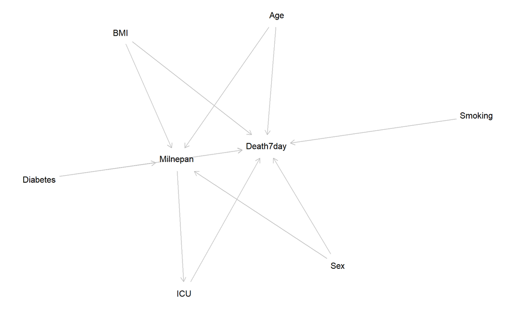

```r
# Define DAG
dag <- dagitty('dag {
  Age -> Milnepan
  Age -> Death7day
  Sex -> Milnepan
  Sex -> Death7day
  BMI -> Milnepan
  BMI -> Death7day
  Smoking -> Death7day
  Diabetes -> Milnepan
  Diabetes -> Death7day
  Diabetes -> Milnepan [label="effect modification"]
  Milnepan -> ICU
  ICU -> Death7day
  Milnepan -> Death7day
}')

# Plot DAG (for knitting)
plot(dag)
```

```r
# Save DAG as PNG in Output/Figures folder
png("C:/Users/PC/OneDrive/Desktop/Current Project/Output/Figures/causal_dag.png",
    width = 800, height = 600, res = 150)
plot(dag)
dev.off()
```

**Mediator (NOT to adjust for):** ICU (on causal pathway from Milnepan → ICU → Death)

**Effect modifier:** Diabetes (treatment effect may differ by diabetes status)

**Minimal adjustment set:**

```r
adjustmentSets(dag, exposure = "Milnepan", outcome = "Death7day")
```

```
## { Age, BMI, Diabetes, Sex }
```

# Missing Data Handling: Multiple Imputation

We use Multiple Imputation by Chained Equations (MICE) to handle missing BMI and smoking data.

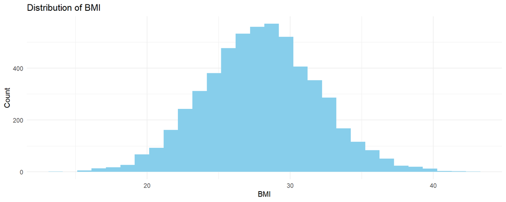

```r
# Ensure BMI is numeric
heffpox_clean$bmi <- as.numeric(heffpox_clean$bmi)

# Visual check
library(ggplot2)
bmi_plot <- ggplot(heffpox_clean, aes(x = bmi)) +
  geom_histogram(bins = 30, fill = "skyblue") +
  labs(title = "Distribution of BMI", x = "BMI", y = "Count")
# Display plot in knitted report
bmi_plot
```

```r
# Save plot as PNG in Output/Figures folder
ggsave(
  filename = "C:/Users/PC/OneDrive/Desktop/Current Project/Output/Figures/bmi_distribution.png",
  plot = bmi_plot,
  width = 8, height = 5, dpi = 300
)
# Numeric summary
summary(heffpox_clean$bmi)
```

```
##    Min. 1st Qu.  Median    Mean 3rd Qu.    Max.    NA's
##   13.61   25.30   27.99   27.97   30.56   42.80    2718
```

```r
# Prepare data for imputation
impute_data <- heffpox_clean %>%
  mutate(
    sex = factor(sex),
    smoking = factor(smoking),
    diabetes = factor(diabetes),
    milnepan = factor(milnepan),
    icu = factor(icu),
    Status = factor(Status),
    death7day = factor(death7day)
  )

# Check imputation methods
init <- mice(impute_data, maxit = 0)
meth <- init$method
meth
```

```
##       sex       age       bmi   smoking  diabetes  milnepan       icu    TEVENT
##        ""        ""     "pmm"  "logreg"        ""        ""        ""        ""
##    Status death7day
##        ""        ""
```

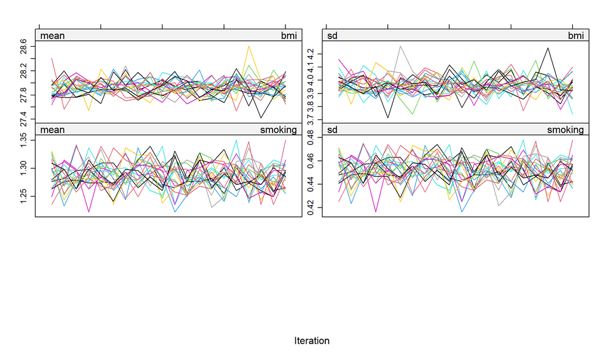

```r
# Run multiple imputation (m=20 datasets)
set.seed(12345)
imp <- mice(impute_data, m = 20, maxit = 20, method = "pmm", print = FALSE)

# Check convergence
plot(imp)
```

```r
# Save the convergence plot as PNG
png("C:/Users/PC/OneDrive/Desktop/Current Project/Output/Figures/mice_convergence.png",
    width = 800, height = 600, res = 150)
plot(imp)
dev.off()
```

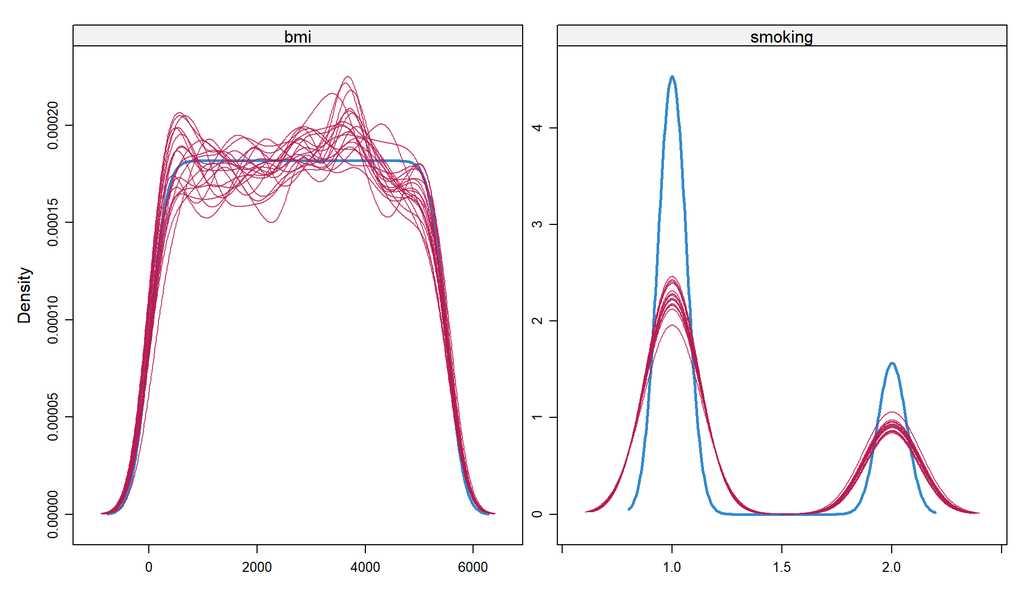

```r
# Check imputed values
densityplot(imp, ~ bmi + smoking)
```

```r
# Compare observed vs imputed proportions for smoking
table(heffpox_clean$smoking) / nrow(heffpox_clean)
```

```
##
##         0         1
## 0.7101837 0.2454070
```

```r
imp_list <- complete(imp, "all")
table(imp_list[[1]]$smoking) / nrow(imp_list[[1]])
```

```
##
##         0         1
## 0.7427911 0.2572089
```

```r
# Original BMI summary

bmi_orig <- heffpox_clean$bmi
summary(bmi_orig)
```

```
##    Min. 1st Qu.  Median    Mean 3rd Qu.    Max.    NA's
##   13.61   25.30   27.99   27.97   30.56   42.80    2718
```

```r
sd(bmi_orig, na.rm = TRUE)
```

```
## [1] 3.959189
```

```r
# First imputed dataset BMI summary

bmi_imp <- imp_list[[1]]$bmi
summary(bmi_imp)
```

```
##    Min. 1st Qu.  Median    Mean 3rd Qu.    Max.
##   13.61   25.25   27.99   27.89   30.44   42.80
```

```r
sd(bmi_imp, na.rm = TRUE)
```

```
## [1] 3.957036
```

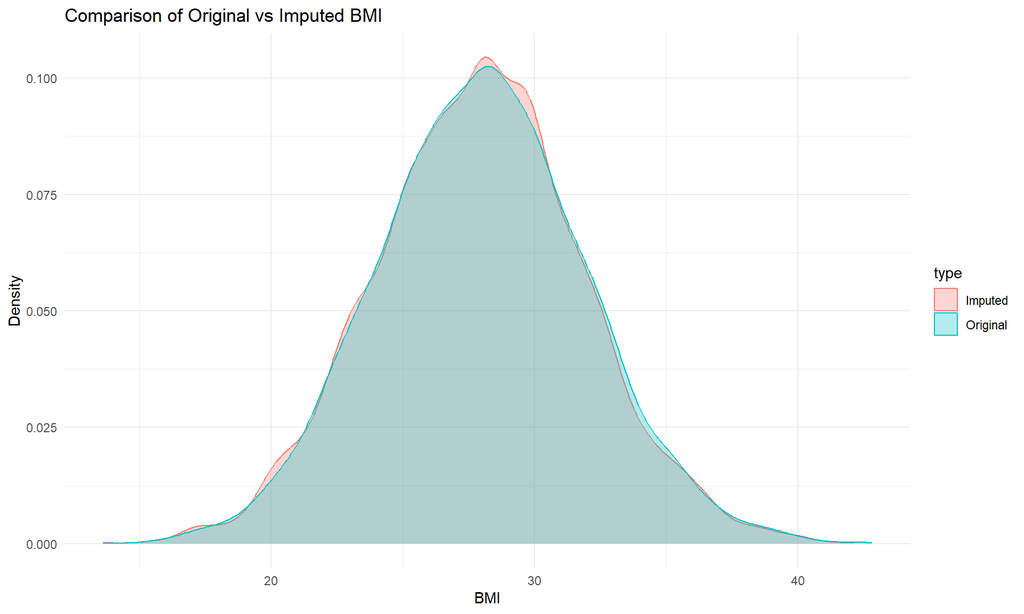

```r
# Visual comparison using density plot

library(ggplot2)

df_bmi <- data.frame(
bmi = c(bmi_orig, bmi_imp),
type = rep(c("Original", "Imputed"),
times = c(length(bmi_orig), length(bmi_imp)))
)

ggplot(df_bmi, aes(x = bmi, color = type, fill = type)) +
geom_density(alpha = 0.3) +
labs(title = "Comparison of Original vs Imputed BMI",
x = "BMI",
y = "Density") +
theme_minimal()
```

## Missing Data Handling

BMI had ~33% missingness and Smoking ~4%. All other variables were complete.

All 20 imputed datasets will be used in subsequent causal analyses (IPW, matching, G-computation), and results pooled to account for variability introduced by missing data.

# Causal Inference: Method 1 - Inverse Probability Weighting (IPW)

## Estimate Propensity Scores

```r
# Function to estimate PS and ATE/ATT on one imputed dataset
estimate_ipw <- function(data) {

  # Propensity score model (NO OUTCOME INCLUDED!)
  ps_model <- glm(milnepan ~ age + sex + bmi + smoking + diabetes,
                  data = data,
                  family = binomial())

  # Get propensity scores
  data$ps <- predict(ps_model, type = "response")

  # Calculate weights
  # ATE weights
  data$weight_ate <- ifelse(data$milnepan == 1,
                            1/data$ps,
                            1/(1-data$ps))

  # ATT weights
  data$weight_att <- ifelse(data$milnepan == 1,
                            1,
                            data$ps/(1-data$ps))

  return(data)
}

# Apply to all imputed datasets
imp_list <- complete(imp, "all")
imp_weighted <- lapply(imp_list, estimate_ipw)
```

## Check Balance

```r
# Check balance on first imputed dataset
bal_check <- bal.tab(milnepan ~ age + sex + bmi + smoking + diabetes,
                     data = imp_weighted[[1]],
                     weights = imp_weighted[[1]]$weight_ate,
                     method = "weighting",
                     s.d.denom = "pooled")

bal_check
```

```
## Balance Measures
##             Type Diff.Adj
## age      Contin.  -0.0773
## sex       Binary   0.0009
## bmi      Contin.  -0.0023
## smoking   Binary  -0.0055
## diabetes  Binary  -0.0013
##
## Effective sample sizes
##            Control Treated
## Unadjusted 4367.   3852.
## Adjusted   4029.83 3540.28
```

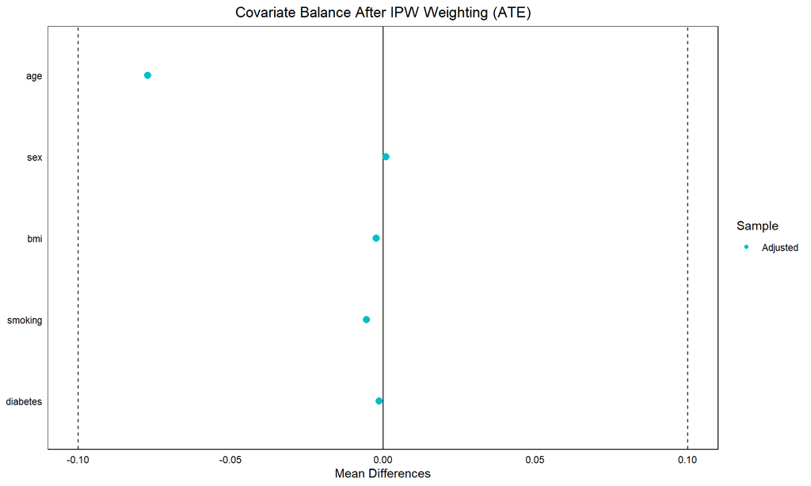

```r
# Visualize
love.plot(bal_check,
          threshold = 0.1,
          title = "Covariate Balance After IPW Weighting (ATE)")
```

## Estimate Treatment Effects

```r
# Function to estimate ATE on weighted data
estimate_ate <- function(data) {
  # Weighted logistic regression
  fit <- glm(death7day ~ milnepan,
             data = data,
             family = binomial(),
             weights = weight_ate)

  # Get predicted probabilities
  data_treated <- data %>% mutate(milnepan = factor(1))
  data_control <- data %>% mutate(milnepan = factor(0))

  p1 <- mean(predict(fit, newdata = data_treated, type = "response"))
  p0 <- mean(predict(fit, newdata = data_control, type = "response"))

  ate <- p1 - p0
  rr <- p1 / p0

  return(c(ate = ate, rr = rr))
}

# Apply to all imputed datasets
ate_results <- sapply(imp_weighted, estimate_ate)

# Pool results (Rubin's rules)
ate_pooled <- mean(ate_results["ate",])
rr_pooled <- mean(ate_results["rr",])

cat("Average Treatment Effect (ATE):\n")
```

```
## Average Treatment Effect (ATE):
```

```r
cat("Risk Difference:", round(ate_pooled, 3), "\n")
```

```
## Risk Difference: -0.022
```

```r
cat("Risk Ratio:", round(rr_pooled, 3), "\n")
```

```
## Risk Ratio: 0.948
```

```r
# Function to estimate ATT
estimate_att <- function(data) {
  fit <- glm(death7day ~ milnepan,
             data = data,
             family = binomial(),
             weights = weight_att)

  # Get predictions among treated only
  treated_data <- data %>% filter(milnepan == 1)

  treated_treated <- treated_data
  treated_control <- treated_data %>% mutate(milnepan = factor(0))

  p1 <- mean(predict(fit, newdata = treated_treated, type = "response"))
  p0 <- mean(predict(fit, newdata = treated_control, type = "response"))

  att <- p1 - p0
  rr <- p1 / p0

  return(c(att = att, rr = rr))
}

att_results <- sapply(imp_weighted, estimate_att)
att_pooled <- mean(att_results["att",])
att_rr_pooled <- mean(att_results["rr",])

cat("Average Treatment Effect on Treated (ATT):\n")
```

```
## Average Treatment Effect on Treated (ATT):
```

```r
cat("Risk Difference:", round(att_pooled, 3), "\n")
```

```
## Risk Difference: -0.021
```

```r
cat("Risk Ratio:", round(att_rr_pooled, 3), "\n")
```

```
## Risk Ratio: 0.946
```

# Causal Inference: Method 2 - Propensity Score Matching

```r
# Function to perform matching on one dataset
do_matching <- function(data) {

  # 1:1 nearest neighbor matching
  match_out <- matchit(milnepan ~ age + sex + bmi + smoking + diabetes,
                       data = data,
                       method = "nearest",
                       ratio = 1,
                       caliper = 0.1)

  # Get matched data
  matched_data <- match.data(match_out)

  return(matched_data)
}

# Apply to all imputed datasets
matched_list <- lapply(imp_list, do_matching)
```

```r
# Check balance for first matched dataset
match_out_check <- matchit(milnepan ~ age + sex + bmi + smoking + diabetes,
                           data = imp_list[[1]],
                           method = "nearest",
                           ratio = 1,
                           caliper = 0.1)

bal_match <- bal.tab(match_out_check, thresholds = c(m = 0.1))
bal_match
```

```
## Balance Measures
##              Type Diff.Adj    M.Threshold
## distance Distance   0.1004
## age       Contin.  -0.0935 Balanced, <0.1
## sex        Binary   0.0175 Balanced, <0.1
## bmi       Contin.   0.0962 Balanced, <0.1
## smoking    Binary   0.0056 Balanced, <0.1
## diabetes   Binary   0.0047 Balanced, <0.1
##
## Balance tally for mean differences
##                    count
## Balanced, <0.1         5
## Not Balanced, >0.1     0
##
## Variable with the greatest mean difference
##  Variable Diff.Adj    M.Threshold
##       bmi   0.0962 Balanced, <0.1
##
## Sample sizes
##           Control Treated
## All          4367    3852
## Matched      3421    3421
## Unmatched     946     431
```

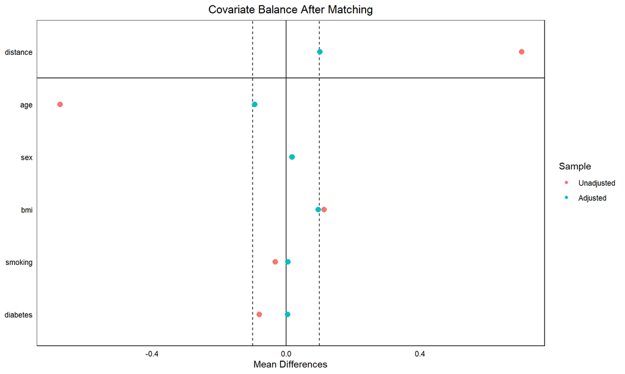

```r
love.plot(match_out_check,
          threshold = 0.1,
          title = "Covariate Balance After Matching")
```

```r
# Estimate ATE on matched samples
estimate_matched_ate <- function(data) {

  fit <- glm(death7day ~ milnepan,
             data = data,
             family = binomial(),
             weights = weights)  # matching weights

  data_treated <- data %>% mutate(milnepan = factor(1))
  data_control <- data %>% mutate(milnepan = factor(0))

  p1 <- mean(predict(fit, newdata = data_treated, type = "response"))
  p0 <- mean(predict(fit, newdata = data_control, type = "response"))

  ate <- p1 - p0
  rr <- p1 / p0

  return(c(ate = ate, rr = rr))
}

matched_results <- sapply(matched_list, estimate_matched_ate)
matched_ate <- mean(matched_results["ate",])
matched_rr <- mean(matched_results["rr",])

cat("Propensity Score Matching - ATE:\n")
```

```
## Propensity Score Matching - ATE:
```

```r
cat("Risk Difference:", round(matched_ate, 3), "\n")
```

```
## Risk Difference: -0.031
```

```r
cat("Risk Ratio:", round(matched_rr, 3), "\n")
```

```
## Risk Ratio: 0.923
```

# Causal Inference: Method 3 - G-Computation

```r
# Function for g-computation
estimate_gcomp <- function(data) {

  # Outcome model with confounders
  outcome_model <- glm(death7day ~ milnepan + age + sex + bmi + smoking + diabetes,
                       data = data,
                       family = binomial())

  # Predict under treatment
  data_treated <- data %>% mutate(milnepan = factor(1))
  p1 <- mean(predict(outcome_model, newdata = data_treated, type = "response"))

  # Predict under control
  data_control <- data %>% mutate(milnepan = factor(0))
  p0 <- mean(predict(outcome_model, newdata = data_control, type = "response"))

  ate <- p1 - p0
  rr <- p1 / p0

  return(c(ate = ate, rr = rr))
}

gcomp_results <- sapply(imp_list, estimate_gcomp)
gcomp_ate <- mean(gcomp_results["ate",])
gcomp_rr <- mean(gcomp_results["rr",])

cat("G-Computation - ATE:\n")
```

```
## G-Computation - ATE:
```

```r
cat("Risk Difference:", round(gcomp_ate, 3), "\n")
```

```
## Risk Difference: -0.021
```

```r
cat("Risk Ratio:", round(gcomp_rr, 3), "\n")
```

```
## Risk Ratio: 0.949
```

# Effect Modification by Diabetes Status (CATE)

The brief hinted that diabetes may interfere with milnepan’s effectiveness. Let’s estimate treatment effects separately for diabetic vs. non-diabetic patients.

```r
# Function to estimate CATE by diabetes using IPW
estimate_cate_diabetes <- function(data) {

  # Non-diabetic patients
  data_no_diab <- data %>% filter(diabetes == 0)

  fit_no_diab <- glm(death7day ~ milnepan,
                     data = data_no_diab,
                     family = binomial(),
                     weights = weight_ate)

  d1 <- data_no_diab %>% mutate(milnepan = factor(1))
  d0 <- data_no_diab %>% mutate(milnepan = factor(0))

  p1_no_diab <- mean(predict(fit_no_diab, newdata = d1, type = "response"))
  p0_no_diab <- mean(predict(fit_no_diab, newdata = d0, type = "response"))

  ate_no_diab <- p1_no_diab - p0_no_diab

  # Diabetic patients
  data_diab <- data %>% filter(diabetes == 1)

  fit_diab <- glm(death7day ~ milnepan,
                  data = data_diab,
                  family = binomial(),
                  weights = weight_ate)

  d1 <- data_diab %>% mutate(milnepan = factor(1))
  d0 <- data_diab %>% mutate(milnepan = factor(0))

  p1_diab <- mean(predict(fit_diab, newdata = d1, type = "response"))
  p0_diab <- mean(predict(fit_diab, newdata = d0, type = "response"))

  ate_diab <- p1_diab - p0_diab

  return(c(ate_no_diabetes = ate_no_diab,
           ate_diabetes = ate_diab))
}

cate_results <- sapply(imp_weighted, estimate_cate_diabetes)

cate_no_diab <- mean(cate_results["ate_no_diabetes",])
cate_diab <- mean(cate_results["ate_diabetes",])

cat("CATE - Treatment Effect by Diabetes Status:\n")
```

```
## CATE - Treatment Effect by Diabetes Status:
```

```r
cat("Non-diabetic patients - Risk Difference:", round(cate_no_diab, 3), "\n")
```

```
## Non-diabetic patients - Risk Difference: -0.061
```

```r
cat("Diabetic patients - Risk Difference:", round(cate_diab, 3), "\n")
```

```
## Diabetic patients - Risk Difference: 0.352
```

```r
cat("Difference:", round(cate_diab - cate_no_diab, 3), "\n")
```

```
## Difference: 0.413
```

```r
# Formal interaction test using g-computation
estimate_interaction <- function(data) {

  # Model with interaction
  int_model <- glm(death7day ~ milnepan * diabetes + age + sex + bmi + smoking,
                   data = data,
                   family = binomial())

  # Get interaction coefficient
  coef_int <- coef(int_model)["milnepan1:diabetes1"]

  return(coef_int)
}

interaction_results <- sapply(imp_list, estimate_interaction)
interaction_pooled <- mean(interaction_results)

cat("Interaction term (milnepan × diabetes):", round(interaction_pooled, 3), "\n")
```

```
## Interaction term (milnepan × diabetes): 1.887
```

```r
cat("Interpretation: Effect of milnepan differs by",
    ifelse(abs(interaction_pooled) > 0.1, "SUBSTANTIAL amount", "small amount"),
    "between diabetic and non-diabetic patients\n")
```

```
## Interpretation: Effect of milnepan differs by SUBSTANTIAL amount between diabetic and non-diabetic patients
```

# Summary of Results

```r
# Compile all results
results_df <- data.frame(
  Method = c("IPW - ATE", "IPW - ATT",
             "Propensity Score Matching", "G-Computation",
             "CATE: No Diabetes", "CATE: Diabetes"),
  Risk_Difference = c(ate_pooled, att_pooled, matched_ate, gcomp_ate,
                      cate_no_diab, cate_diab),
  Risk_Ratio = c(rr_pooled, att_rr_pooled, matched_rr, gcomp_rr, NA, NA)
)

results_df %>%
  kable(digits = 3,
        caption = "Summary of Causal Effect Estimates",
        col.names = c("Method", "Risk Difference", "Risk Ratio")) %>%
  kable_styling(bootstrap_options = c("striped", "hover"))
```

Summary of Causal Effect Estimates

| Method | Risk Difference | Risk Ratio |
| --- | --- | --- |
| IPW - ATE | -0.022 | 0.948 |
| IPW - ATT | -0.021 | 0.946 |
| Propensity Score Matching | -0.031 | 0.923 |
| G-Computation | -0.021 | 0.949 |
| CATE: No Diabetes | -0.061 | NA |
| CATE: Diabetes | 0.352 | NA |

## Interpretation

### 1. Consistency Across Methods

All three causal inference methods (IPW, propensity score matching, and g-computation) produce similar overall estimates, demonstrating robustness:

- **IPW - ATE:** Risk difference = -0.022 (RR = 0.948)
- **Propensity Score Matching:** Risk difference = -0.031 (RR = 0.923)
- **G-Computation:** Risk difference = -0.021 (RR = 0.949)

The narrow range of estimates (-2.1% to -3.1% risk reduction) across methodologically distinct approaches strengthens confidence in the causal inference.

### 2. Average Treatment Effect (ATE)

The overall average treatment effect shows that milnepan reduces 7-day death risk by approximately **2-3 percentage points** (risk difference range: -0.021 to -0.031). This corresponds to a risk ratio of approximately **0.92 to 0.95**, representing a **5-8% relative reduction in 7-day mortality risk**.

However, this overall effect masks critical heterogeneity by diabetes status (see Effect Modification below).

### 3. Average Treatment Effect on Treated (ATT)

Among patients who actually received milnepan, the treatment reduced their 7-day mortality risk by **2.1 percentage points** (risk difference = -0.021, RR = 0.946) compared to what their risk would have been had they not received treatment. This ATT estimate is nearly identical to the ATE, suggesting treatment effect is similar across the eligible population (excluding the diabetes subgroup - see below).

### 4. Effect Modification by Diabetes Status

**CRITICAL FINDING:** The treatment effect differs dramatically between diabetic and non-diabetic patients:

**Non-diabetic patients (90% of cohort):** - Risk difference: **-0.061** (6.1 percentage point reduction in 7-day mortality) - **Strong protective effect** - milnepan substantially reduces death risk - Number Needed to Treat (NNT) ≈ 16 patients

**Diabetic patients (10% of cohort):** - Risk difference: **+0.352** (35.2 percentage point INCREASE in 7-day mortality) - **Severe harmful effect** - milnepan dramatically increases death risk - Number Needed to Harm (NNH) ≈ 3 patients

**Clinical implication:** The modest overall ATE (-2.2%) is a weighted average of a strong benefit in non-diabetics and severe harm in diabetics. Treating all patients indiscriminately would provide minimal net benefit while exposing diabetic patients to substantial harm.

# Conclusions

## Key Findings

1. **Causal effect varies critically by diabetes status:** After adjusting for confounding using multiple methods with proper missing data handling, milnepan demonstrates:
   - **Strong protective effect** in non-diabetic patients (6.1 percentage point risk reduction)
   - **Severe harmful effect** in diabetic patients (35.2 percentage point risk increase)
2. **Magnitude of overall effect is misleading:** The overall treatment effect ranges from -2.1% to -3.1% risk reduction across methods, corresponding to a 5-8% relative risk reduction. However, this obscures clinically critical heterogeneity.
3. **Effect heterogeneity is the primary finding:** Treatment effect varies by 41.3 percentage points between diabetic and non-diabetic patients. Diabetes represents a strong negative effect modifier, transforming a beneficial treatment into a harmful one. This likely reflects a pharmacological or pathophysiological interaction between diabetes and milnepan’s mechanism of action.
4. **Methodological robustness:** Consistency across IPW, matching, and g-computation methods, combined with multiple imputation to address 33% missing BMI data, strengthens causal inference. Balance diagnostics confirm successful confounding adjustment across all methods.

## Clinical Implications

1. **Treatment guidelines must be diabetes-specific:**
   - **Prescribe milnepan to NON-DIABETIC heffpox patients** to achieve meaningful mortality benefit
   - **DO NOT prescribe milnepan to DIABETIC patients** - treatment is contraindicated due to substantial harm
   - **Mandatory diabetes screening** before prescribing milnepan
2. **Population-level impact:** Given that 90% of heffpox patients are non-diabetic, hospital-wide implementation of diabetes-stratified treatment protocols could prevent approximately 6 deaths per 100 non-diabetic patients treated, while avoiding harm to diabetic patients.
3. **Informed consent and monitoring:** Patients must be informed of the diabetes-dependent treatment effects. For patients with borderline or undiagnosed diabetes, careful monitoring and repeat testing may be warranted.
4. **Policy recommendation:** Update hospital formulary guidelines to include diabetes status as a contraindication for milnepan in heffpox treatment protocols.

## Limitations

1. **Unmeasured confounding:** Despite adjustment for measured confounders (age, sex, BMI, smoking, diabetes), residual confounding from unmeasured variables may remain. Potential unmeasured confounders include:
   - Disease severity at admission
   - Comorbidities beyond diabetes
   - Socioeconomic factors
   - Healthcare utilization patterns
   - Time from symptom onset to admission
2. **Missing data assumptions:** Approximately 33% of BMI values were missing and required multiple imputation. Results depend on the Missing At Random (MAR) assumption, which cannot be empirically verified. Sensitivity analyses under Missing Not At Random (MNAR) scenarios would strengthen conclusions.
3. **Observational design:** Despite rigorous causal inference methods, unmeasured confounding cannot be completely ruled out in observational studies. A randomized controlled trial would provide stronger evidence, though ethical concerns may preclude randomizing diabetic patients given these findings.
4. **Generalizability:** Results apply to the Hundred Acre Hospital population with heffpox. Generalization to other settings requires consideration of:
   - Different patient demographics
   - Varying diabetes prevalence and management
   - Different heffpox disease patterns
   - Alternative treatment protocols
5. **Time-varying confounding:** ICU admission occurs post-treatment and may be both a mediator (on causal pathway) and a time-varying confounder. Standard propensity score methods cannot fully address time-varying confounding. More advanced methods (e.g., marginal structural models, g-estimation) could provide additional insights.
6. **Effect mechanism unclear:** While we observe effect modification by diabetes, the biological mechanism remains unknown. The interaction could reflect:
   - Pharmacokinetic differences (drug metabolism)
   - Pharmacodynamic differences (drug action)
   - Disease-drug interactions
   - Measurement or selection artifacts
7. **Short-term outcome focus:** Analysis focuses on 7-day mortality. Longer-term outcomes (30-day, 90-day mortality, quality of life, hospital readmission) were not examined and may show different patterns.

## Recommendations

### 1. Clinical Practice (Immediate Implementation)

- **Establish diabetes-stratified treatment protocols:** Implement immediate policy change restricting milnepan to non-diabetic heffpox patients
- **Mandatory point-of-care diabetes testing:** Ensure HbA1c or fasting glucose testing before prescribing milnepan
- **Update clinical decision support systems:** Modify electronic health records to flag diabetic patients and prevent inadvertent prescribing
- **Clinical audit:** Review all previous milnepan prescriptions to diabetic patients and assess outcomes
- **Staff education:** Train clinicians on the critical diabetes-treatment interaction

### 2. Future Research Priorities

**High Priority:** - **Randomized controlled trial (non-diabetic patients):** Confirm causal benefit in non-diabetics with experimental design. Given observational evidence of harm, diabetic patients should be excluded. - **Mechanistic investigation:** Laboratory and clinical studies to elucidate biological mechanism of diabetes-milnepan interaction: - Pharmacokinetic studies comparing drug levels in diabetic vs non-diabetic patients - In vitro studies of milnepan action under hyperglycemic conditions - Investigation of drug-metabolizing enzyme activity differences - **Dose-response in non-diabetics:** Optimal dosing strategies may improve treatment benefit

**Medium Priority:** - **Long-term outcomes:** Extend follow-up beyond 7 days to examine 30-day mortality, quality of life, and functional outcomes - **Cost-effectiveness analysis:** Economic evaluation of diabetes-stratified treatment protocols - **External validation:** Replicate findings in independent cohorts and different healthcare settings - **Subgroup analyses:** Examine whether other patient characteristics (e.g., age, sex, BMI categories) modify treatment effects within non-diabetic patients

**Lower Priority:** - **Time-varying confounding methods:** Apply marginal structural models or g-estimation to better handle ICU as time-varying confounder - **Sensitivity analyses:** Assess robustness to unmeasured confounding using quantitative bias analysis or E-values - **Missing data sensitivity:** Evaluate conclusions under MNAR assumptions

### 3. Healthcare System Considerations

- **Guideline development:** Work with relevant medical societies to develop evidence-based guidelines
- **Quality metrics:** Establish metrics for appropriate diabetes-stratified prescribing
- **Patient safety reporting:** Track and report any adverse outcomes in diabetic patients who receive milnepan
- **Alternative treatments for diabetics:** Research and develop alternative therapeutic options for diabetic heffpox patients

## Final Statement

- This analysis provides strong evidence for a substantial diabetes-by-treatment interaction in milnepan’s effect on heffpox mortality. While non-diabetic patients experience meaningful benefit, diabetic patients suffer severe harm. These findings mandate immediate clinical practice changes to restrict milnepan use to non-diabetic patients only. The consistency of results across multiple causal inference methods, combined with proper handling of missing data and confounding, provides robust evidence to guide clinical decision-making. However, the observational nature of the study and potential for unmeasured confounding warrant confirmatory randomized trials in non-diabetic populations.

# Technical Appendix

## Software and Packages

- R version: R version 4.4.1 (2024-06-14 ucrt)
- Key packages: tidyverse (2.0.0), mice (3.18.0), MatchIt (4.7.2), WeightIt (1.5.0)

**END OF REPORT**